# Psychoinformatics - Week 4 (Exercises)

by 蕭柏圓 (b08207078@ntu.edu.tw)

## 1 Analyze what videos go viral? (8 points)

Please use [YouTube APIs](https://developers.google.com/youtube/v3/code_samples/python) to carry out a data-driven or hypothesis-driven microstudy about the characteristics of viral videos.

You need to present, here in this notebook, AT LEAST two **statistical** figures or tables as supporting evidence for your arguments. Each of these figures/tables deserves 4 points.

```python
# Please carry out your analysis here
from apiclient.discovery import build
```

```python
DEVELOPER_KEY = "AIzaSyB3suUnrFRCIzhEjqvd7W8xqDif0c62Juo"
```

```python
def youtube_popular(part,max_results,token=None,location_radius=None):

    youtube = build('youtube','v3',developerKey=DEVELOPER_KEY)

    response = youtube.videos().list(
    part=part,
    chart='mostPopular',
    regionCode='TW',maxResults=max_results).execute()

    title = []
    channelId = []
    channelTitle = []
    categoryId = []
    viewCount = []
    likeCount = []
    dislikeCount = []
    commentCount = []
    favoriteCount = []
    category = []
    videos = []
    duration = []

    youtube_dict = {
        "2":"Autos&Vehicles",
        "1":"Film&Animation",
        "10":"Music",
        "15":"Pets&Animals",
        "20":"Gaming",
        "22":"People&Blogs",
        "23":"Comedy",
        "24":"Entertainment",
        "25":"News&Politics",
        "27":"Education"
        }

    for i in range(len(response["items"])):
        title.append(response['items'][i]['snippet']['title'])
        channelId.append(response['items'][i]['snippet']['channelId'])
        channelTitle.append(response['items'][i]['snippet']['channelTitle'])
        categoryId.append(youtube_dict[response['items'][i]['snippet']['categoryId']])
        favoriteCount.append(float(response['items'][i]['statistics']['favoriteCount']))
        viewCount.append(float(response['items'][i]['statistics']['viewCount']))

        a = response['items'][i]['contentDetails']['duration']
        if "H" in a and "M" in a:
            h = a.split("T")[1].split("H")[0]
            m = a.split("T")[1].split("H")[1].split("M")[0]
            s = a.split("T")[1].split("H")[1].split("M")[1].split("S")[0]
        elif "H" in a:
            h = a.split("T")[1].split("H")[0]
            m = 0
            s = a.split("T")[1].split("H")[1].split("S")[0]
        elif "M" in a:
            h = 0
            m = a.split("T")[1].split("M")[0]
            s = a.split("T")[1].split("M")[1].split("S")[0]
        else:
            h, m = 0, 0
            s = a.split("T")[1].split("S")[0]
        if h == "":
            h = 0
        if m == "":
            m = 0
        if s == "":
            s = 0
        a = 3600*float(h) + 60*float(m) + float(s)
        duration.append(a)

        #likeCount.append(response['items'][i]['statistics']['likeCount'])
        #dislikeCount.append(response['items'][i]['statistics']['dislikeCount'])

        if 'commentCount' in response['items'][i]['statistics'].keys():
            commentCount.append(float(response['items'][i]['statistics']['commentCount']))
        else:
            commentCount.append([])
        try:
            likeCount.append(float(response['items'][i]['statistics']['likeCount']))
        except KeyError as l:
            likeCount.append(0)
        try:
            dislikeCount.append(float(response['items'][i]['statistics']['dislikeCount']))
        except KeyError as l:
            dislikeCount.append(0)

    youtube_dict = {'title':title,'channelTitle': channelTitle,'channelId': channelId,'categoryId':categoryId,'duration':duration,'viewCount':viewCount,'likeCount':likeCount,'dislikeCount':dislikeCount,'commentCount':commentCount,'favoriteCount':favoriteCount}

    return youtube_dict
```

```python
import pandas as pd
test = youtube_popular(part='id, snippet,statistics,contentDetails', max_results = 50)
df_y = pd.DataFrame(data=test)
df_y.head()
```

|  | title | channelTitle | channelId | categoryId | duration | viewCount | likeCount | dislikeCount | commentCount | favoriteCount |
| --- | --- | --- | --- | --- | --- | --- | --- | --- | --- | --- |
| 0 | 聽見玻璃心碎的聲音... 黃明志 Ft.陳芳語【玻璃心】@鬼才做音樂 2021 Ghosician | Namewee | UCFUtqTcgJgRnmZ3tMU6P74Q | Music | 295.0 | 13108249.0 | 578809.0 | 14407.0 | 120050.0 | 0.0 |
| 1 | 被「換臉」成謎片主角只能自認倒霉？Deep Fake 的傷害有多大？｜志祺七七 ft. 魚乾... | 志祺七七 X 圖文不符 | UCiWXd0nmBjlKROwzMyPV-Nw | People&Blogs | 1406.0 | 446354.0 | 22439.0 | 424.0 | 2896.0 | 0.0 |
| 2 | 【#狗屎寫手】ＱＱㄋㄟㄋㄟ的出處｜#Chill革命 現場版｜ @喬瑟夫 ChillSeph | STR Network | UCDrswN-SqWh7Kii62h9aXGA | Entertainment | 375.0 | 312815.0 | 14011.0 | 96.0 | 726.0 | 0.0 |
| 3 | 請不要對號入座... 黃明志 Ft.陳芳語【玻璃心】MV 製作花絮 | Namewee | UCFUtqTcgJgRnmZ3tMU6P74Q | Entertainment | 774.0 | 542695.0 | 37770.0 | 432.0 | 3346.0 | 0.0 |
| 4 | 陳柏惟總統級造勢.警犬巡邏! 46死陳其邁不辭職只說不停止檢討! 公祭降半旗 蔡英文只停3分... | 新聞大白話 | UC5fkmrA5VDTr2IU7lPmpsHA | News&Politics | 14250.0 | 231481.0 | 14596.0 | 236.0 | 149.0 | 0.0 |

```python
rank = range(50,0,-1)
popular = ["very high"]*17 + ["high"]*17 + ["a little high"]*16  # 依照排名高低分成三組
df_yy = df_y.copy()
df_yy["rank"]= rank
df_yy["popular"]= popular
df_yy.head()
```

|  | title | channelTitle | channelId | categoryId | duration | viewCount | likeCount | dislikeCount | commentCount | favoriteCount | rank | popular |
| --- | --- | --- | --- | --- | --- | --- | --- | --- | --- | --- | --- | --- |
| 0 | 聽見玻璃心碎的聲音... 黃明志 Ft.陳芳語【玻璃心】@鬼才做音樂 2021 Ghosician | Namewee | UCFUtqTcgJgRnmZ3tMU6P74Q | Music | 295.0 | 13108249.0 | 578809.0 | 14407.0 | 120050.0 | 0.0 | 50 | very high |
| 1 | 被「換臉」成謎片主角只能自認倒霉？Deep Fake 的傷害有多大？｜志祺七七 ft. 魚乾... | 志祺七七 X 圖文不符 | UCiWXd0nmBjlKROwzMyPV-Nw | People&Blogs | 1406.0 | 446354.0 | 22439.0 | 424.0 | 2896.0 | 0.0 | 49 | very high |
| 2 | 【#狗屎寫手】ＱＱㄋㄟㄋㄟ的出處｜#Chill革命 現場版｜ @喬瑟夫 ChillSeph | STR Network | UCDrswN-SqWh7Kii62h9aXGA | Entertainment | 375.0 | 312815.0 | 14011.0 | 96.0 | 726.0 | 0.0 | 48 | very high |
| 3 | 請不要對號入座... 黃明志 Ft.陳芳語【玻璃心】MV 製作花絮 | Namewee | UCFUtqTcgJgRnmZ3tMU6P74Q | Entertainment | 774.0 | 542695.0 | 37770.0 | 432.0 | 3346.0 | 0.0 | 47 | very high |
| 4 | 陳柏惟總統級造勢.警犬巡邏! 46死陳其邁不辭職只說不停止檢討! 公祭降半旗 蔡英文只停3分... | 新聞大白話 | UC5fkmrA5VDTr2IU7lPmpsHA | News&Politics | 14250.0 | 231481.0 | 14596.0 | 236.0 | 149.0 | 0.0 | 46 | very high |

## Histgram of categoryID

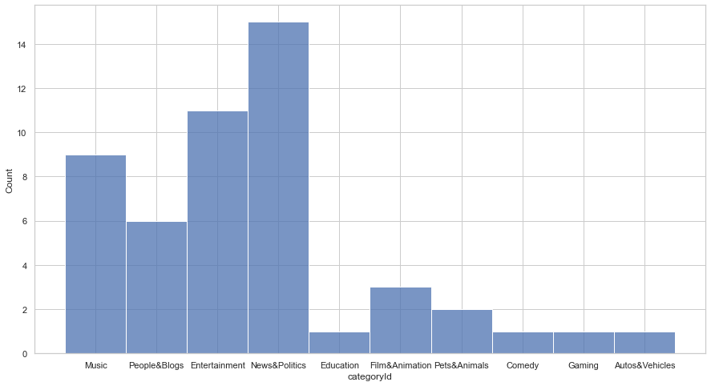

```python
import seaborn as sns
from matplotlib import pyplot as plt

sns.set_theme(style="whitegrid")
plt.figure(figsize=(15,8))
colors = sns.color_palette("Blues")
sns.histplot(data=df_yy, x="categoryId", stat="count", discrete=True)
plt.show()
```

小結：  
第一部分，我對這筆資料進行的描述統計是，我想要知道在youtube發燒榜上面的影片種類有哪些，於是就製作了分析影片種類的數量長條圖。  
結果可以發現，這些發燒影片的特質前三名分別是：

1. **新聞＆政治類**是最多的（新聞highlight、新聞直播等等）
2. **娛樂類**（STR Network、綜藝玩很大等等）
3. **音樂類**（黃明志和陳芳語的「聽見玻璃心碎的聲音」、IU的「Strewberry moon」等等）

## Correlation and simple regression

### Simple regression graphs

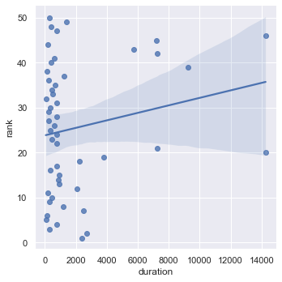

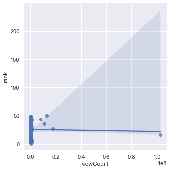

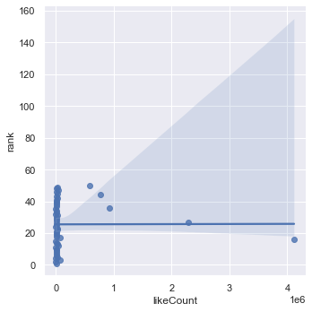

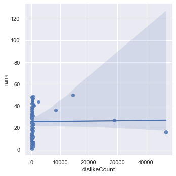

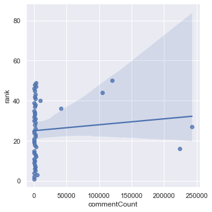

```python
import seaborn as sns
statss = ["duration","viewCount","likeCount","dislikeCount","commentCount"]
for sta in statss:
    sns.set_theme()
    sns.lmplot(
        data=df_yy,
        x=sta, y="rank",
        height=5
    )
```

### Pearson correlation

```python
from scipy import stats

# Pearson correlation
r = [0]*5
p = [0]*5
statss = ["duration","viewCount","likeCount","dislikeCount","commentCount"]
for i in range(len(statss)):
    rval, prob = stats.pearsonr(df_yy[statss[i]],df_yy["rank"])
    r[i] = rval
    p[i] = prob
data = {'r':r, 'p value':p}
df_pearson = pd.DataFrame(data, index =statss)
df_pearson
```

|  | r | p value |
| --- | --- | --- |
| duration | 0.189285 | 0.187997 |
| viewCount | -0.036673 | 0.800390 |
| likeCount | 0.003432 | 0.981131 |
| dislikeCount | 0.015924 | 0.912603 |
| commentCount | 0.101996 | 0.480920 |

小結：  
第三部分，我將第二部分的可視化圖形，用數據表格來呈現，也就是使用 **Pearson correlation** 來看各自兩者的相關。  
結果可以發現：

1. 與在第二部分預測的相符，相關最大的是發燒影片的排名和其影片長度，初步推測這樣的結果有可能driven by一些常常卡在高排名的新聞直播影片（有的長度都是好幾個小時）。
2. 但是這四組的相關仍然太低了，使得p值均沒有通過顯著(p=0.05)。

因此，我認為，或許連續資料的相關分析不適合用在發燒影片的排名上面，所以在下一個部分將會使用 **Spearman rank correlation** 來進行分析。

### Spearman rank correlation

```python
from scipy import stats

# Spearman rank correlation
r = [0]*5
p = [0]*5
statss = ["duration","viewCount","likeCount","dislikeCount","commentCount"]
for i in range(len(statss)):
    rval, prob = stats.spearmanr(df_yy[statss[i]],df_yy["rank"])
    r[i] = rval
    p[i] = prob
data = {'r':r, 'p value':p}
df_spearman = pd.DataFrame(data, index =statss)
df_spearman
```

|  | r | p value |
| --- | --- | --- |
| duration | 0.025355 | 0.861254 |
| viewCount | 0.101657 | 0.482390 |
| likeCount | 0.275006 | 0.053255 |
| dislikeCount | 0.273201 | 0.054901 |
| commentCount | 0.211454 | 0.140451 |

小結：  
第四部分，使用Spearman rank correaltion來進行發燒影片排名與五個數據的相關分析，將結果整理於附表。  
結果發現：

1. 原本有高相關的發燒影片排名和其影片長度，變成最低的了，可見好像事實上兩者之間的關係並沒有想像中那麼高。
2. 有兩個數據接近顯著(**邊緣顯著**)，也就是**影片讚數**和**影片倒讚數**，它們可能才是影響發燒影片排名的因素

### likeCount and dislikeCount

```
r = 0.9814575057519519, p = 4.2709593183280714e-36
```

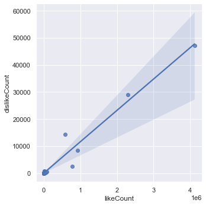

```python
from scipy import stats
import seaborn as sns

r, prob = stats.pearsonr(df_yy['likeCount'],df_yy["dislikeCount"])
print("r = " + str(r) + ", p = " + str(prob))
sns.set_theme()
sns.lmplot(data=df_yy,x='likeCount', y="dislikeCount", height=5)
```

小結：  
第四部分的補充，原本我是假設讚數和倒讚數應該會呈現負相關，但事實上卻不是如此。  
結果顯示，在這些發燒影片中有一個特質，那就是讚數和倒讚數的**相關高達0.98**，換句話說，**擁有較高讚數的影片就會吸引到更多的倒讚**。  
而再結合第四部分的結果，不管是讚數，還是倒讚數，都可能為發燒影片的排名帶來幫助。

## Multiple Regression of rank and five stats

### 假設五個數值可以預測排名

```python
import numpy as np
import statsmodels.api as sm
import statsmodels.formula.api as smf

results = smf.ols('rank ~ duration + viewCount + likeCount + dislikeCount + commentCount', data=df_yy).fit()
print(results.summary())
```

```
                            OLS Regression Results
==============================================================================
Dep. Variable:                   rank   R-squared:                       0.123
Model:                            OLS   Adj. R-squared:                  0.023
Method:                 Least Squares   F-statistic:                     1.230
Date:                Sat, 23 Oct 2021   Prob (F-statistic):              0.311
Time:                        19:49:28   Log-Likelihood:                -201.14
No. Observations:                  50   AIC:                             414.3
Df Residuals:                      44   BIC:                             425.8
Df Model:                           5
Covariance Type:            nonrobust
================================================================================
                   coef    std err          t      P>|t|      [0.025      0.975]
--------------------------------------------------------------------------------
Intercept       22.6735      2.551      8.887      0.000      17.532      27.815
duration         0.0010      0.001      1.580      0.121      -0.000       0.002
viewCount     5.183e-07   6.13e-07      0.845      0.403   -7.18e-07    1.75e-06
likeCount    -2.043e-05   2.13e-05     -0.962      0.342   -6.33e-05    2.24e-05
dislikeCount    -0.0009      0.002     -0.586      0.561      -0.004       0.002
commentCount     0.0003      0.000      1.833      0.074   -3.12e-05       0.001
==============================================================================
Omnibus:                        7.427   Durbin-Watson:                   0.181
Prob(Omnibus):                  0.024   Jarque-Bera (JB):                2.448
Skew:                           0.015   Prob(JB):                        0.294
Kurtosis:                       1.916   Cond. No.                     1.88e+07
==============================================================================

Notes:
[1] Standard Errors assume that the covariance matrix of the errors is correctly specified.
[2] The condition number is large, 1.88e+07. This might indicate that there are
strong multicollinearity or other numerical problems.
```

小結：  
第五部分，我假設可以用第二部分的五個數值來預測發燒影片的排名。  
因此我利用**OLS的Model fitting**，進行對發燒影片排名的多元迴歸，而x變項我選擇的是將第二部分的五個數據作為變數放進迴歸模型中。  
結果可以發現：

1. 所有係數的p value都**不顯著**，最小仍**高達0.074**。
2. 此模型的**預測力(R-squared和Adj. R-squared)很低**，只有**2.3%**而已。

### 假設影片類別和五個數據有關

```python
results = smf.ols('viewCount ~ C(categoryId) + duration + likeCount + dislikeCount + commentCount', data=df_yy).fit()
print(results.summary())
```

```
                            OLS Regression Results
==============================================================================
Dep. Variable:              viewCount   R-squared:                       0.952
Model:                            OLS   Adj. R-squared:                  0.935
Method:                 Least Squares   F-statistic:                     54.81
Date:                Sat, 23 Oct 2021   Prob (F-statistic):           1.00e-19
Time:                        21:18:04   Log-Likelihood:                -819.81
No. Observations:                  50   AIC:                             1668.
Df Residuals:                      36   BIC:                             1694.
Df Model:                          13
Covariance Type:            nonrobust
===================================================================================================
                                      coef    std err          t      P>|t|      [0.025      0.975]
---------------------------------------------------------------------------------------------------
Intercept                        3.331e+05   3.77e+06      0.088      0.930   -7.31e+06    7.98e+06
C(categoryId)[T.Comedy]          9.991e+05   5.33e+06      0.188      0.852    -9.8e+06    1.18e+07
C(categoryId)[T.Education]      -1.888e+05   5.33e+06     -0.035      0.972    -1.1e+07    1.06e+07
C(categoryId)[T.Entertainment]  -1.066e+06   3.94e+06     -0.271      0.788   -9.05e+06    6.92e+06
C(categoryId)[T.Film&Animation]  1.534e+05   4.35e+06      0.035      0.972   -8.67e+06    8.97e+06
C(categoryId)[T.Gaming]          -4.44e+05   5.33e+06     -0.083      0.934   -1.13e+07    1.04e+07
C(categoryId)[T.Music]           2.223e+06   4.11e+06      0.541      0.592    -6.1e+06    1.05e+07
C(categoryId)[T.News&Politics]  -4.631e+04   3.96e+06     -0.012      0.991   -8.07e+06    7.98e+06
C(categoryId)[T.People&Blogs]   -3.075e+05   4.07e+06     -0.076      0.940   -8.56e+06    7.94e+06
C(categoryId)[T.Pets&Animals]   -1.671e+05   4.61e+06     -0.036      0.971   -9.52e+06    9.19e+06
duration                          -47.5937    190.346     -0.250      0.804    -433.633     338.446
likeCount                          23.3249      4.192      5.564      0.000      14.822      31.827
dislikeCount                     1053.6605    383.386      2.748      0.009     276.117    1831.204
commentCount                     -231.5453     31.325     -7.392      0.000    -295.075    -168.016
==============================================================================
Omnibus:                       21.102   Durbin-Watson:                   1.765
Prob(Omnibus):                  0.000   Jarque-Bera (JB):              108.954
Skew:                          -0.651   Prob(JB):                     2.19e-24
Kurtosis:                      10.113   Cond. No.                     1.59e+07
==============================================================================

Notes:
[1] Standard Errors assume that the covariance matrix of the errors is correctly specified.
[2] The condition number is large, 1.59e+07. This might indicate that there are
strong multicollinearity or other numerical problems.
```

小結：  
第六部分，我假設發燒影片的觀看數可以用影片類型再加上另外四個數據來預測。  
因此我利用**OLS的Model fitting**，進行對發燒影片觀看數的多元迴歸。  
結果可以發現：

1. 除了 **likeCount** 和 **dislikeCount** 和 **commentCount** 之外，其他係數的結果都不顯著
2. 此模型的**預測力(R-squared和Adj. R-squared)很高**，竟然高達**93.5%**。

因此，我認為，做為y變項的發燒影片 **viewCount** 以及做為x變項的發燒影片 **likeCount** 和 **dislikeCount** 和 **commentCount** 可能具有共線性，才會導致第五部分以及第六部分的其他變項都不顯著，而自己獨自顯著，而且模型預測力還非常高。

### 檢查共線性

```python
results = smf.ols('viewCount ~ likeCount + dislikeCount + commentCount', data=df_yy).fit()
print(results.summary())
```

```
                            OLS Regression Results
==============================================================================
Dep. Variable:              viewCount   R-squared:                       0.948
Model:                            OLS   Adj. R-squared:                  0.944
Method:                 Least Squares   F-statistic:                     278.7
Date:                Sat, 23 Oct 2021   Prob (F-statistic):           1.68e-29
Time:                        19:19:38   Log-Likelihood:                -821.83
No. Observations:                  50   AIC:                             1652.
Df Residuals:                      46   BIC:                             1659.
Df Model:                           3
Covariance Type:            nonrobust
================================================================================
                   coef    std err          t      P>|t|      [0.025      0.975]
--------------------------------------------------------------------------------
Intercept     1.718e+05   5.15e+05      0.334      0.740   -8.65e+05    1.21e+06
likeCount       22.8850      3.844      5.953      0.000      15.147      30.623
dislikeCount  1037.8390    351.754      2.950      0.005     329.795    1745.883
commentCount  -212.1031     26.522     -7.997      0.000    -265.489    -158.717
==============================================================================
Omnibus:                       24.383   Durbin-Watson:                   1.880
Prob(Omnibus):                  0.000   Jarque-Bera (JB):              155.204
Skew:                          -0.754   Prob(JB):                     1.99e-34
Kurtosis:                      11.499   Cond. No.                     7.30e+05
==============================================================================

Notes:
[1] Standard Errors assume that the covariance matrix of the errors is correctly specified.
[2] The condition number is large, 7.3e+05. This might indicate that there are
strong multicollinearity or other numerical problems.
```

小結：  
第七部分，我要來驗證我的假設。  
根據第六部分的結果，我假設我的多元回歸之所以失敗，可能是因為做為y變項的發燒影片 **viewCount** 以及做為x變項的發燒影片 **likeCount** 和 **dislikeCount** 和 **commentCount** 可能具有共線性。  
因此我利用**OLS的Model fitting**，進行對發燒影片這些數據的多元迴歸。  
結果可以發現：

做為y變項的發燒影片 **viewCount** 以及做為x變項的發燒影片 **likeCount** 和 **dislikeCount** 和 **commentCount** 確實具有高度的共線性，這有可能就是造成多元回歸失敗的原因，也就是說，可能沒辦法這樣把所有因素都放到同一個回歸式中進行model fitting，或許還有其他的變項（例如 **觀看次數的成長速率**、**觀看次數的平台來源** 等等）才是可能可以預測發燒影片排名的因素。

```python
import scipy.stats as st
# 假設五個數值在不同condition下有差異

sha = []
lev = []
anova = []
statss = ["duration","viewCount","likeCount","dislikeCount","commentCount"]
for sta in statss:
    alist = df_yy[df_yy['popular'] == 'very high'][sta].tolist()
    blist = df_yy[df_yy['popular'] == 'high'][sta].tolist()
    clist = df_yy[df_yy['popular'] == 'a little high'][sta].tolist()

    shaa = []
    shaa.append('%.3e' % st.shapiro(alist)[1])
    shaa.append('%.3e' % st.shapiro(blist)[1])
    shaa.append('%.3e' % st.shapiro(clist)[1])
    sha.append(shaa)

    lev.append(st.levene(alist, blist, clist, center='mean')[1])

    anova.append(st.f_oneway(alist, blist, clist)[1])
data = {'ShapiroResult: p value':sha, 'LeveneResult: p value':lev, 'ANOVA: p value':anova}
df_anova = pd.DataFrame(data, index =statss)
df_anova
```

|  | ShapiroResult: p value | LeveneResult: p value | ANOVA: p value |
| --- | --- | --- | --- |
| duration | [1.395e-04, 3.264e-06, 1.048e-02] | 0.003097 | 0.237304 |
| viewCount | [3.836e-06, 7.124e-08, 5.281e-08] | 0.059800 | 0.538245 |
| likeCount | [2.024e-06, 2.942e-08, 5.580e-08] | 0.391347 | 0.836527 |
| dislikeCount | [1.011e-06, 3.003e-08, 5.661e-08] | 0.428067 | 0.864810 |
| commentCount | [1.692e-06, 2.642e-08, 5.750e-08] | 0.995290 | 0.991430 |

小結：  
最後一部份，我假設Youtube發燒影片的排名高低，其實會對第二部分的五個數據造成顯著的差異。  
因此，我將發燒影片(第一名~第五十名)依照排名高低分成三組，發燒影片前17名是popular "very high"組別、中間17名是popular "high"組別、最後16名是popular "a little high"組別，我想去分析看看第二部分的五個數據在這三個組別中，會不會有顯著差異。  
我所要進行的分析是One-way ANOVA，而心統、心測、心實都不斷強調，要進行ANOVA之前要先對資料進行常態性(Shapiro–Wilk test，具有常態性需要 **p value > 0.05** )和變異數同質性(Levene's Test of Equal Variances，具有變異數同質性需要 **p value > 0.05** )的檢定，之後才能進行ANOVA的分析以及推論，所以我將常態性和變異數同質性的檢定結果以及ANOVA的結果一併整理在上表中。  
從結果中我們可以發現：

1. Shapiro–Wilk test：其實任何一組都沒有符合常態性，我覺得很可能就是這種worldwide的資料常常會差異很大，很可能會呈現多峰的分佈。
2. Levene's Test of Equal Variances：只有 **影片長度** 那組小於0.05，以及 **觀看數** 那組是位於顯著邊緣，其他組合都是符合變異數同質性。
3. One-way ANOVA：沒有任何一組通過顯著，有可能是因為所有的常態性檢定根本都沒有通過，也有可能是這樣對發燒影片的分組使得 **這五個數據在各組之間沒有顯著差異**。

*總結而言，發燒影片排名選擇的機制看起來不是這樣抓幾筆數據就可以被解釋的，而是很值得好好去探討的，因為有了這樣的模型及演算法，才能讓我們在使用者端有很優質的觀賞影片體驗。*

# Please submit this file to NTU COOL before next Monday (10/25).